# rPanglaoDB Application Case: **Fibrocytes**

To show the potential of rPanglaoDB for collecting rare cell types by integrating multiple public datasets, we present a biological application collecting and characterizing a set of fibrocytes.

```r
set.seed(1)
library(rPanglaoDB)
library(Seurat)
library(harmony)
library(Nebulosa)
library(ggplot2)
library(ggrepel)
library(enrichR)
library(fgsea)
library(GSVA)
library(statsExpressions)
BIOP <- gmtPathways('https://maayanlab.cloud/Enrichr/geneSetLibrary?mode=text&libraryName=BioPlanet_2019')
```

Fibrocytes are marrow-derived cells that can differentiate into fibroblasts from monocyte precursors. These cells exhibit both the inflammatory features of macrophages and the tissue remodeling properties of fibroblasts. They are present at wound sites where they participate in tissue injury repair and remodeling [[21597472]](https://pubmed.ncbi.nlm.nih.gov/21597472/). Due to the lack of an unbiased characterization of their transcriptome, their marker genes are missed in all the databases used by the tools designed to assign cell-types automatically from single-cell RNA-seq data such as [MSigDB](http://www.gsea-msigdb.org/gsea/msigdb/genesets.jsp?collection=C8) [[21546393]](https://pubmed.ncbi.nlm.nih.gov/21546393/), [ClusterMole](https://cran.rstudio.com/web/packages/clustermole/index.html), and [PanglaoDB](https://panglaodb.se/markers.html?cell_type=%27choose%27) [[30951143]](https://pubmed.ncbi.nlm.nih.gov/30951143/). Fibrocytes differentiate from fibroblasts and macrophages by expressing *CD34* [[8790603](https://pubmed.ncbi.nlm.nih.gov/8790603/), [19834619](https://pubmed.ncbi.nlm.nih.gov/19834619/)]. They differentiate also from macrophages by expressing *ACTA2*, *FAP*, *FN1*, *COL5A1*, *COL5A2*, *COL5A3*, *CD90*, and the lack of *CSF1R*, and also differentiate from fibroblasts by expressing *CHIT1*, *MME*, *SIRPA*, *PTPRC*, and *ICAM1* among others [[21597472]](https://pubmed.ncbi.nlm.nih.gov/21597472/).

Using the `getMarkers` function, we identified a cluster of cells in the [SRS3121028](https://www.ncbi.nlm.nih.gov/sra/?term=SRR6936914) sample derived from skin wound tissues (3 days after scab detachment) expressing *CD34*, *ACTA2*, *FN1*, *Collagen V*, *FAP*, *SIRPA* and the lack of expression of *CSF1R*. Genes that differentiate fibrocytes from macrophages and fibroblasts [[30464171]](https://pubmed.ncbi.nlm.nih.gov/30464171/)(Lim, et al., 2018; Pilling, et al., 2009; Reilkoff, et al., 2011).

```r
FibrocytesClusters <- getMarkers(
  include = c('CD34', 'ACTA2', 'FN1', 'COL5A1', 'COL5A2', 'COL5A3', 'FAP', 'SIRPA'),
  exclude = 'CSF1R')

FibrocytesClusters
```

|  | SRA | SRS | Specie | Tissue | Cluster | Cell-Type | Markers |
| --- | --- | --- | --- | --- | --- | --- | --- |
| 1 | SRA681285 | SRS3121028 | Mus musculus | Dermis | 4 | Fibroblasts | +CD34+ACTA2+FN1+COL5A1+COL5A2+COL5A3+FAP+SIRPA-CSF1R |

Since, fibrocytes are marrow-derived cells that differentiate into fibroblasts-like phenotypes, they are usually wrong labeled as fibroblasts. Thus, we downloaded using the `getSamples` function all the fibroblasts available from dermis samples in the database (SRA accessions: SRS3121028 and SRS3121030) [[30464171]](https://pubmed.ncbi.nlm.nih.gov/30464171/).

```r
FibrocytesCounts <- getSamples(tissue = 'Dermis', specie = 'Mus musculus', celltype = 'Fibroblasts')
```

```
  |                                                  | 0 % ~calculating
  |+++++++++++++++++++++++++                         | 50% ~01m 07s
  |++++++++++++++++++++++++++++++++++++++++++++++++++| 100% elapsed=01m 41s
```

```r
FibrocytesCounts
```

```
An object of class Seurat
31380 features across 2172 samples within 1 assay
Active assay: RNA (31380 features, 0 variable features)
```

We merged a total of 2,172 cells and processed them using the Seurat package recommended pipeline (Stuart, et al., 2019). Datasets were integrated using Harmony.

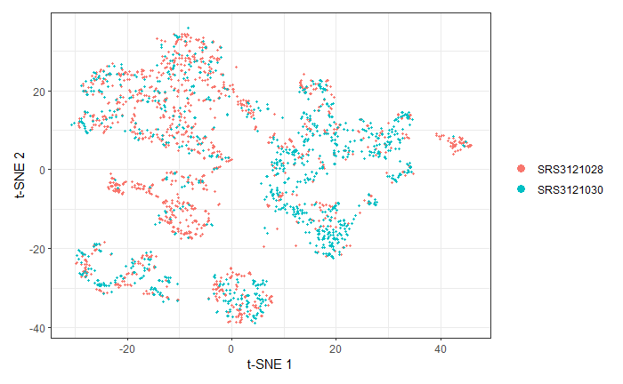

```r
FibrocytesCounts <- NormalizeData(FibrocytesCounts, verbose = FALSE)
FibrocytesCounts <- ScaleData(FibrocytesCounts, verbose = FALSE)
FibrocytesCounts <- FindVariableFeatures(FibrocytesCounts, verbose = FALSE)
FibrocytesCounts <- RunPCA(FibrocytesCounts, verbose = FALSE)
FibrocytesCounts <- RunHarmony(FibrocytesCounts,
                               group.by.vars = 'orig.ident',
                               max.iter.harmony = 50,
                               verbose = FALSE)
FibrocytesCounts <- RunTSNE(FibrocytesCounts, reduction = 'harmony', dims = 1:10)
TSNEPlot(FibrocytesCounts) + theme_bw() + xlab('t-SNE 1') + ylab('t-SNE 2')
```

```r
FibrocytesCounts <- FindNeighbors(FibrocytesCounts, reduction = 'harmony', verbose = FALSE)
```

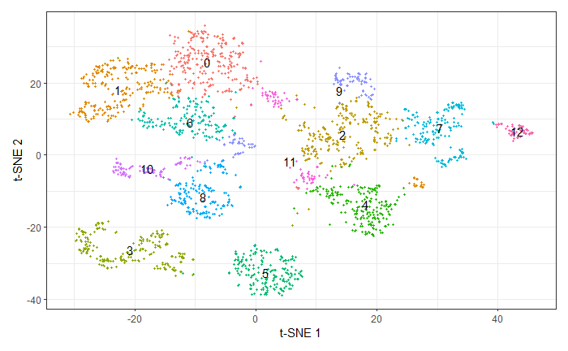

```r
FibrocytesCounts <- FindClusters(FibrocytesCounts, verbose = FALSE)
TSNEPlot(FibrocytesCounts, label = TRUE) + theme_bw() + xlab('t-SNE 1') + ylab('t-SNE 2') + theme(legend.position = 'None')
```

Corroboration of the expression for the marker genes defining the cellular identity as fibrocytes (*CD34*, *ACTA2*, *COL5A1*, *COL5A2*, *COL5A3*, *FN1*, *FAP*, *SIRPA*, *PTPRC*, *MME*, and *SEMA7A*) was assessed using the Nebulosa package

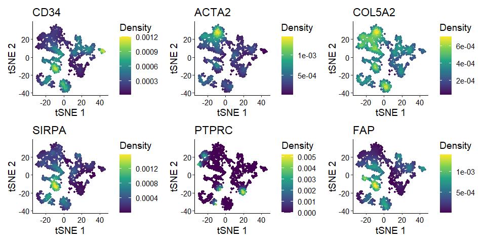

```r
plot_density(object = FibrocytesCounts,
             features = c('CD34','ACTA2', 'COL5A2', 'SIRPA', 'PTPRC', 'FAP'),
             joint = FALSE)
```

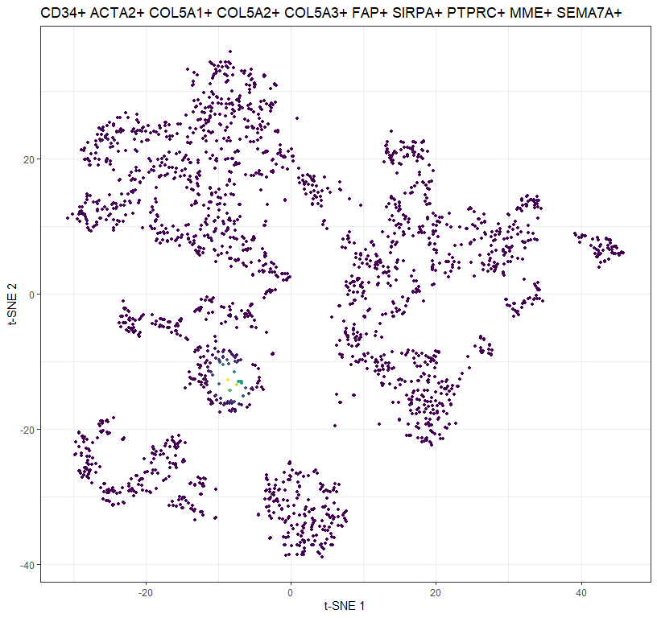

```r
P <- plot_density(object = FibrocytesCounts,
                  features = c('CD34', 'ACTA2', 'COL5A1', 'COL5A2', 'COL5A3', 'FAP', 'SIRPA', 'PTPRC', 'MME', 'SEMA7A'),
                  joint = TRUE)
P[[11]] + theme_bw() + xlab('t-SNE 1') + ylab('t-SNE 2') + theme(legend.position = 'None')
```

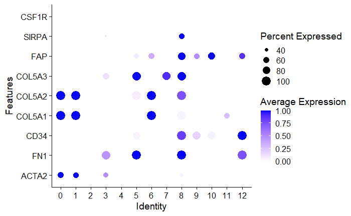

```r
DotPlot(object = FibrocytesCounts,
        scale.by = 'size',
        scale = TRUE,
        dot.min = 0.3,
        cols = c('white', 'blue'),
        col.min = 0,
        col.max = 1,
        features = c('ACTA2', 'FN1', 'CD34', 'COL5A1', 'COL5A2', 'COL5A3', 'FAP', 'SIRPA', 'CSF1R')) +
  coord_flip()
```

```r
table(Idents(FibrocytesCounts))
```

```
  0   1   2   3   4   5   6   7   8   9  10  11  12
253 249 244 218 200 195 163 163 157 111  87  79  53
```

```r
deFibrocytes <- FindMarkers(object = FibrocytesCounts, ident.1 = 8, test.use = 'MAST', verbose = FALSE)
```

```r
upR_Fibrocytes <- rownames(deFibrocytes[deFibrocytes$avg_log2FC > 1 & deFibrocytes$p_val_adj < 0.05,])
upR_Enrichment <- enrichr(upR_Fibrocytes, databases = 'BioPlanet_2019')[[1]]
```

```
Uploading data to Enrichr... Done.
  Querying BioPlanet_2019... Done.
Parsing results... Done.
```

```r
upR_Enrichment[upR_Enrichment$Adjusted.P.value < 0.05,]
```

|  | Term | Overlap | P.value | Adjusted.P.value | Old.P.value | Old.Adjusted.P.value | Odds.Ratio | Combined.Score | Genes |
| --- | --- | --- | --- | --- | --- | --- | --- | --- | --- |
| 1 | TGF-beta regulation of extracellular matrix | 13/565 | 8.664479e-10 | 1.117718e-07 | 0 | 0 | 12.346945 | 257.63899 | TNFAIP6;ELN;FN1;SOD3;TM4SF1;MFAP5;SFRP4;EFEMP1;DPYSL2;CD34;CD55;S100A10;FBN1 |
| 2 | ECM-receptor interaction | 4/84 | 5.754824e-05 | 2.704762e-03 | 0 | 0 | 21.597826 | 210.85714 | TNXB;FN1;CD44;THBS3 |
| 3 | Prostaglandin biosynthesis and regulation | 3/31 | 6.290143e-05 | 2.704762e-03 | 0 | 0 | 45.414894 | 439.34103 | ANXA3;ANXA5;S100A10 |
| 4 | Notch signaling pathway | 4/121 | 2.367473e-04 | 7.635099e-03 | 0 | 0 | 14.740245 | 123.05919 | MFAP5;FHL1;ENO1;DLK1 |
| 5 | Interleukin-5 regulation of apoptosis | 4/144 | 4.589729e-04 | 1.184150e-02 | 0 | 0 | 12.304348 | 94.57761 | ANXA3;ENO1;CD44;CD55 |
| 6 | Integrin beta-5 pathway | 2/17 | 8.132713e-04 | 1.748533e-02 | 0 | 0 | 55.375000 | 393.96243 | FN1;FBN1 |
| 7 | Oncostatin M | 5/311 | 1.051870e-03 | 1.938447e-02 | 0 | 0 | 7.132898 | 48.91160 | ECM1;LDHA;ANXA3;FN1;IGFBP6 |
| 8 | Hematopoietic cell lineage | 3/88 | 1.389345e-03 | 2.240318e-02 | 0 | 0 | 14.917397 | 98.14041 | CD34;CD44;CD55 |
| 9 | Inflammatory response pathway | 2/30 | 2.547877e-03 | 3.651957e-02 | 0 | 0 | 29.645833 | 177.05958 | FN1;THBS3 |

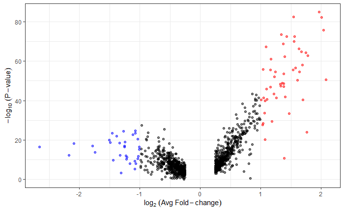

```r
deFibrocytes$g <- rownames(deFibrocytes)
deFibrocytes$g[abs(deFibrocytes$avg_log2FC) < 1] <- NA
deFibrocytes$F <- log2(deFibrocytes$pct.1/deFibrocytes$pct.2)
deFibrocytes$g[abs(deFibrocytes$F) < 1] <- NA
deFibrocytes$color <- 'black'
deFibrocytes$color[deFibrocytes$avg_log2FC > 1] <- 'red'
deFibrocytes$color[deFibrocytes$avg_log2FC < -1] <- 'blue'
ggplot(deFibrocytes, mapping = aes(avg_log2FC, -log10(p_val), label = g)) +
  geom_point(color = deFibrocytes$color, alpha = 0.5) +
  geom_text_repel() +
  theme_bw() + xlab(log[2]~(Avg~Fold-change)) +
  ylab(-log[10]~(P-value))
```

```r
log2FC <- deFibrocytes$avg_log2FC
names(log2FC) <- rownames(deFibrocytes)
set.seed(1)
enrichmentFibrocytes <- fgseaMultilevel(BIOP, log2FC)
enrichmentFibrocytes <- enrichmentFibrocytes[enrichmentFibrocytes$padj < 0.05,]
enrichmentFibrocytes$leadingEdge <- unlist(lapply(enrichmentFibrocytes$leadingEdge, function(X){paste0(X, collapse = ';')}))
enrichmentFibrocytes <- enrichmentFibrocytes[order(enrichmentFibrocytes$NES, decreasing = TRUE),]
enrichmentFibrocytes
```

| pathway | pval | padj | log2err | ES | NES | size | leadingEdge |
| --- | --- | --- | --- | --- | --- | --- | --- |
| Prostaglandin biosynthesis and regulation | 9.021596e-05 | 1.121685e-02 | 0.5384341 | 0.7181070 | 2.246657 | 12 | ANXA3;S100A10;ANXA5;ANXA2;PTGIS;ANXA1;S100A6;PTGS1;HPGD |
| Disease | 2.203846e-04 | 2.466104e-02 | 0.5188481 | -0.3179851 | -1.933270 | 110 | IGFBP2;CPE;NR4A1;IGFBP4;CDKN1A;IGFBP3;RPL37;RPS26;RPL37A;RPS27;IGF1;RPS28;RPL41;RPS19;RPL35A;RPL39;RPL18A;RPS23;RPL36A;RPS21;RPS29;RPL27;RPL30;HCK;MYC;RPLP2;RPL28;RPL36;RPS18;FAU;MFGE8;RPS16;RPS15A;RP… |
| Retinoblastoma protein regulation | 4.417374e-05 | 6.178801e-03 | 0.5573322 | -0.8961268 | -2.142426 | 5 | CEBPB;CDKN1A;MEF2C;CDKN2A;JUN |
| Gene expression | 1.646503e-05 | 3.070728e-03 | 0.5756103 | -0.3625119 | -2.152780 | 98 | NR4A1;JUNB;RPL37;RPS26;RPL37A;RPS27;RPS28;RPL41;RPS19;RPL35A;RPL39;RPL18A;NR4A2;RPS23;RPL36A;RPS21;RPS29;RPL27;RPL30;MYC;RPLP2;RPL28;RPL36;RPS18;FAU;RPS16;RPS15A;RPL21;RPS14;RPL23;RPS13;TGIF1;EEF2;RPL… |
| Activation of mRNA upon binding of the cap-binding complex and eIFs, and subsequent binding to 43S | 2.858372e-05 | 4.569312e-03 | 0.5756103 | -0.5285906 | -2.369178 | 32 | RPS26;RPS27;RPS28;RPS19;RPS23;RPS21;RPS29;RPS18;FAU;RPS16;RPS15A;RPS14;RPS13;RPS20;EIF3H;RPS9;RPSA;RPS6;RPS11;RPS15;RPS25;RPS27A;EIF5;RPS5;RPS2;RPS12;RPS10 |
| Cap-dependent translation initiation | 7.937264e-06 | 1.776360e-03 | 0.5933255 | -0.5095368 | -2.438813 | 40 | RPL37;RPL37A;RPL41;RPL35A;RPL39;RPL18A;RPL36A;RPL27;RPL30;RPLP2;RPL28;RPL36;RPL21;RPL23;RPL17;RPL38;RPL10A;RPLP0;RPL27A;RPL3;EIF3H;RPL7;RPL15;RPL9;RPL6;RPL13A;EIF5;RPL19;RPL4;RPL32;RPL31;RPLP1;RPL18;R… |
| Translation | 3.285211e-08 | 9.190377e-06 | 0.7195128 | -0.4703525 | -2.650647 | 74 | RPL37;RPS26;RPL37A;RPS27;RPS28;RPL41;RPS19;RPL35A;RPL39;RPL18A;RPS23;RPL36A;RPS21;RPS29;RPL22L1;RPL27;RPL30;RPLP2;RPL28;RPL36;RPS18;FAU;RPS16;RPS15A;RPL21;RPS14;RPL23;RPS13;EEF2;RPL17;RPS20;RPL38;RPL1… |
| Influenza infection | 3.118142e-09 | 1.163067e-06 | 0.7749390 | -0.5060263 | -2.797912 | 65 | RPL37;RPS26;RPL37A;RPS27;RPS28;RPL41;RPS19;RPL35A;RPL39;RPL18A;RPS23;RPL36A;RPS21;RPS29;RPL27;RPL30;RPLP2;RPL28;RPL36;RPS18;FAU;RPS16;RPS15A;RPL21;RPS14;RPL23;RPS13;RPL17;RPS20;RPL38;RPL10A;RPLP0;RPL2… |
| Influenza viral RNA transcription and replication | 5.114741e-10 | 2.861698e-07 | 0.8012156 | -0.5377449 | -2.935556 | 63 | RPL37;RPS26;RPL37A;RPS27;RPS28;RPL41;RPS19;RPL35A;RPL39;RPL18A;RPS23;RPL36A;RPS21;RPS29;RPL27;RPL30;RPLP2;RPL28;RPL36;RPS18;FAU;RPS16;RPS15A;RPL21;RPS14;RPL23;RPS13;RPL17;RPS20;RPL38;RPL10A;RPLP0;RPL2… |
| Cytoplasmic ribosomal proteins | 4.119778e-10 | 2.861698e-07 | 0.8140358 | -0.5388799 | -2.959475 | 64 | RPL37;RPS26;RPL37A;RPS27;RPS28;RPL41;RPS19;RPL35A;RPL39;RPL18A;RPS23;RPL36A;RPS21;RPS29;RPL27;RPL30;RPLP2;RPL28;RPL36;RPS18;FAU;RPS16;RPS15A;RPL21;RPS14;RPL23;RPS13;RPL17;RPS20;RPL38;RPL10A;RPLP0;RPL2… |

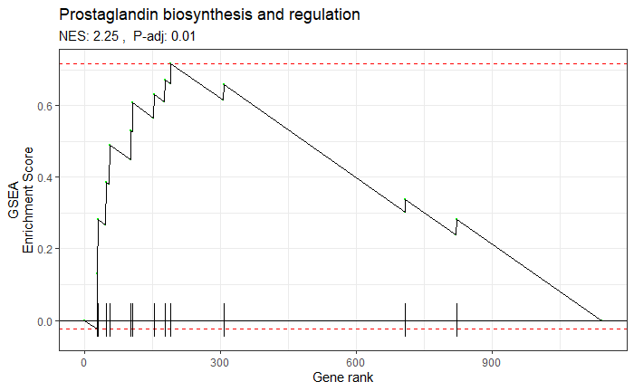

```r
plotEnrichment(BIOP$`Prostaglandin biosynthesis and regulation`, log2FC) +
  geom_line(color = 'black') +
  theme_bw() +
  ylab('GSEA\nEnrichment Score') +
  xlab('Gene rank') +
  labs(title = 'Prostaglandin biosynthesis and regulation',
       subtitle = paste0('NES: ', round(enrichmentFibrocytes$NES[1],2), ' ,  P-adj: ', round(enrichmentFibrocytes$padj[1],2)))
```

```r
sseBIOP <- gsva(as.matrix(FibrocytesCounts@assays$RNA@data), BIOP, method = 'ssgsea')
```

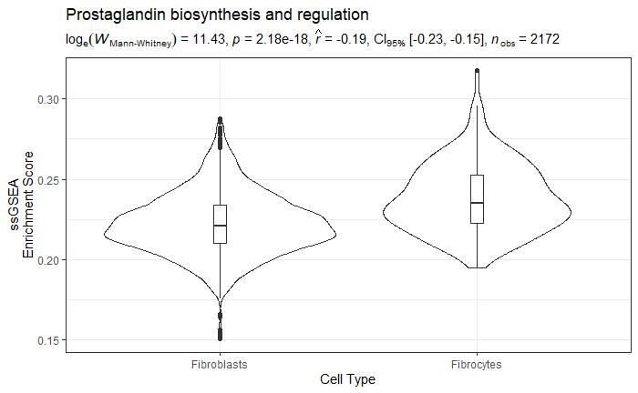

```r
cellType <- ifelse(FibrocytesCounts$seurat_clusters %in% 8, 'Fibrocytes', 'Fibroblasts')
esFibrocytes <- data.frame(ES = sseBIOP['Prostaglandin biosynthesis and regulation',], CT = cellType)
ggplot(esFibrocytes, aes(CT, ES)) +
  geom_violin() +
  geom_boxplot(width = 0.05) +
  theme_bw() +
  xlab('Cell Type') +
  ylab('ssGSEA\nEnrichment Score') +
  labs(title = 'Prostaglandin biosynthesis and regulation',
       subtitle = expr_t_nonparametric(esFibrocytes, CT, ES))
```